# Feature Engineering

Tier A/B feature builders — kept as two separate functions rather than one with a flag, so it's structurally hard to accidentally mix submission-time and post-hoc features — target definition (preferring the practically useful "used" memory quantity over allocated, where available) and log1p transforms (execution time, memory, and power are all heavy-tailed), failed-job exclusion (a job that never finished doesn't have a meaningful duration or power draw to predict), and embedding dimensionality reduction (F-DATA's job-name embedding is a privacy-irreversible 384-dim vector, PCA-reduced before any model sees it).

See the conceptualization plan and EXPERIMENT_TRACKER.md for full context.

```python
import sys
sys.path.append("..")

import numpy as np
import pandas as pd
import matplotlib.pyplot as plt

from src import config, features, metrics, plotting, models, roofline
```

## Load data

Same `SAMPLE_SIZE` dev-sample pattern as notebook 01 — see `EXPERIMENT_TRACKER.md` for when this needs to step up toward the full dataset.

```python
FDATA_DIR = "../data/raw/fdata"
PM100_PATH = "../data/raw/pm100/pm100_job_table.parquet"
SAMPLE_SIZE = 5000

# Same rationale as notebook 01: with all 38 months present, do NOT load
# every file in full before sampling — the embedding column alone would
# need ~100GB+ for all ~26M rows. Load a handful of files, sample from
# that smaller pool instead.
N_FILES_FOR_SAMPLE = 5

import glob
fdata_files = sorted(glob.glob(f"{FDATA_DIR}/*.parquet"))

rng = np.random.RandomState(0)
sampled_files = sorted(rng.choice(fdata_files, size=min(N_FILES_FOR_SAMPLE, len(fdata_files)), replace=False))
print(f"Loading {len(sampled_files)} of {len(fdata_files)} files: {sampled_files}")

fdata = pd.concat([pd.read_parquet(f) for f in sampled_files], ignore_index=True)
pm100 = pd.read_parquet(PM100_PATH)

if SAMPLE_SIZE is not None:
    fdata = fdata.sample(n=min(SAMPLE_SIZE, len(fdata)), random_state=0).reset_index(drop=True)
    pm100 = pm100.sample(n=min(SAMPLE_SIZE, len(pm100)), random_state=0).reset_index(drop=True)

FDATA_DATETIME_COLS = ["adt", "qdt", "schedsdt", "deldt", "sdt", "edt"]
for c in FDATA_DATETIME_COLS:
    fdata[c] = pd.to_datetime(fdata[c], errors="coerce")
pm100["submit_time"] = pd.to_datetime(pm100["submit_time"], unit="s", errors="coerce")
pm100["start_time"] = pd.to_datetime(pm100["start_time"], unit="s", errors="coerce")
pm100["end_time"] = pd.to_datetime(pm100["end_time"], unit="s", errors="coerce")

print("fdata:", fdata.shape, " pm100:", pm100.shape)
```

```
Loading 5 of 38 files: [np.str_('../data/raw/fdata/22_02.parquet'), np.str_('../data/raw/fdata/22_06.parquet'), np.str_('../data/raw/fdata/22_07.parquet'), np.str_('../data/raw/fdata/23_01.parquet'), np.str_('../data/raw/fdata/23_08.parquet')]
```

```
fdata: (5000, 45)  pm100: (5000, 35)
```

## Step 1: Exclude failed/cancelled/killed jobs

Their duration/power are artifacts of failure, not real workload behavior. F-DATA's `exit state` is a clean completed/failed binary; PM100's `job_state` has 6 values, only `COMPLETED` reflects normal execution.

```python
print("F-DATA exit state breakdown:")
print(fdata["exit state"].value_counts())
print("\nPM100 job_state breakdown:")
print(pm100["job_state"].value_counts())

fdata = features.filter_completed_jobs(fdata, "fdata")
pm100 = features.filter_completed_jobs(pm100, "pm100")
```

```
F-DATA exit state breakdown:
exit state
completed    4721
failed        279
Name: count, dtype: int64

PM100 job_state breakdown:
job_state
COMPLETED        3952
FAILED            627
CANCELLED         208
TIMEOUT           196
OUT_OF_MEMORY      16
NODE_FAIL           1
Name: count, dtype: int64
[fdata] excluded 5.6% of jobs as non-completed (279 / 5000)
[pm100] excluded 21.0% of jobs as non-completed (1048 / 5000)
```

## Step 1b: PM100 "missing-by-design" fields — Feature Vetting

Three PM100 columns showed very different missingness rates in notebook 01's EDA: `num_tasks` (4.1%), `req_nodes` (88.6%), `threads_per_core` (99.6%). The severity gap between these is a signal worth chasing rather than treating all three the same way — this section documents a reusable **Feature Vetting** method applied to each candidate derived feature before it's allowed into the active Tier A set: (1) check whether the missingness reflects a genuine optional flag vs. ordinary incomplete logging, (2) measure the effect size against all three targets, (3) check for redundancy with existing categorical features, and (4) check for user-concentration — whether the signal is a broad pattern or a handful of users' individual signature. All checks below run against the **full** PM100 dataset (231,238 jobs), not the `SAMPLE_SIZE` dev sample used elsewhere in this notebook, since concentration/effect-size conclusions need the real population.

```python
pm100_full = pd.read_parquet(PM100_PATH)
pm100_full_completed = pm100_full[pm100_full["job_state"] == "COMPLETED"].copy()

print("=== Missingness on the FULL dataset (not the dev sample) ===")
for c in ["num_tasks", "req_nodes", "threads_per_core"]:
    n_missing = pm100_full[c].isna().sum()
    print(f"{c}: {n_missing:,} / {len(pm100_full):,} ({n_missing/len(pm100_full):.1%})")

print("\n=== req_nodes non-null values look like specific node IDs, not free text ===")
print(pm100_full["req_nodes"].dropna().head(5).tolist())
print("\n=== threads_per_core non-null value counts (Slurm SMT override: 1/2/4) ===")
print(pm100_full["threads_per_core"].value_counts(dropna=False).head(5))
```

```
=== Missingness on the FULL dataset (not the dev sample) ===
num_tasks: 9,457 / 231,238 (4.1%)
req_nodes: 204,942 / 231,238 (88.6%)
threads_per_core: 230,334 / 231,238 (99.6%)

=== req_nodes non-null values look like specific node IDs, not free text ===
['[763]', '[878]', '[94]', '[773]', '[206]']

=== threads_per_core non-null value counts (Slurm SMT override: 1/2/4) ===
threads_per_core
NaN    230334
1.0       884
4.0        16
2.0         4
Name: count, dtype: int64
```

**Interpretation:** `req_nodes`'s non-null values are literal node-ID lists (Slurm's `--nodelist` flag — pinning a job to specific named hardware). `threads_per_core`'s only non-null values are 1, 2, or 4 (Slurm's `--threads-per-core` SMT override). Both are genuine **optional request parameters that are null by design** for the vast majority of jobs that don't use them — not a data quality defect. `num_tasks` has no such documented optional-flag semantics; its missingness looks like ordinary incomplete logging.

### Check 1: Effect size against all three targets

A statistically significant difference alone isn't enough evidence at this sample size (n≈180k completed jobs) — even trivial effects will show significant p-values. Comparing **median** target values between flag=True and flag=False groups, with a Mann-Whitney U test as a secondary check, not the primary evidence.

```python
from scipy import stats

pm100_full_completed["node_pinned"] = pm100_full_completed["req_nodes"].notna()
pm100_full_completed["threads_per_core_set"] = pm100_full_completed["threads_per_core"].notna()
pm100_full_completed["num_tasks_missing"] = pm100_full_completed["num_tasks"].isna()
pm100_full_completed["power_mean"] = pm100_full_completed["node_power_consumption"].apply(lambda a: float(np.mean(a)))

flags = ["node_pinned", "threads_per_core_set", "num_tasks_missing"]
target_cols = {"run_time": "run_time", "mem_alloc": "mem_alloc", "power_mean": "power_mean"}

effect_size_rows = []
for flag in flags:
    for tname, tcol in target_cols.items():
        group_true = pm100_full_completed.loc[pm100_full_completed[flag], tcol]
        group_false = pm100_full_completed.loc[~pm100_full_completed[flag], tcol]
        _, p = stats.mannwhitneyu(group_true, group_false, alternative="two-sided")
        effect_size_rows.append({
            "flag": flag, "target": tname,
            "median_true": group_true.median(), "median_false": group_false.median(),
            "ratio": group_true.median() / group_false.median() if group_false.median() else np.nan,
            "p_value": p, "n_true": int(pm100_full_completed[flag].sum()),
        })

effect_size_df = pd.DataFrame(effect_size_rows)
effect_size_df
```

|  | flag | target | median_true | median_false | ratio | p_value | n_true |
| --- | --- | --- | --- | --- | --- | --- | --- |
| 0 | node_pinned | run_time | 185.000000 | 215.000000 | 0.860465 | 1.049630e-146 | 23130 |
| 1 | node_pinned | mem_alloc | 237.000000 | 237.000000 | 1.000000 | 0.000000e+00 | 23130 |
| 2 | node_pinned | power_mean | 540.000000 | 830.000000 | 0.650602 | 0.000000e+00 | 23130 |
| 3 | threads_per_core_set | run_time | 730.000000 | 189.000000 | 3.862434 | 4.085747e-47 | 672 |
| 4 | threads_per_core_set | mem_alloc | 59.000000 | 237.000000 | 0.248945 | 2.762573e-235 | 672 |
| 5 | threads_per_core_set | power_mean | 575.643939 | 790.000000 | 0.728663 | 1.697607e-58 | 672 |
| 6 | num_tasks_missing | run_time | 360.000000 | 187.000000 | 1.925134 | 6.029560e-24 | 7735 |
| 7 | num_tasks_missing | mem_alloc | 240.000000 | 237.000000 | 1.012658 | 4.791964e-187 | 7735 |
| 8 | num_tasks_missing | power_mean | 1110.000000 | 786.666667 | 1.411017 | 9.480880e-251 | 7735 |

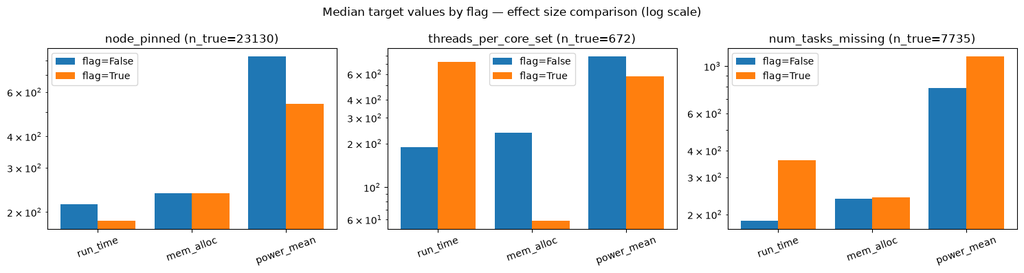

```python
fig, axes = plt.subplots(1, 3, figsize=(15, 4))
for ax, flag in zip(axes, flags):
    sub = effect_size_df[effect_size_df["flag"] == flag]
    x = np.arange(len(sub))
    ax.bar(x - 0.2, sub["median_false"], width=0.4, label="flag=False")
    ax.bar(x + 0.2, sub["median_true"], width=0.4, label="flag=True")
    ax.set_xticks(x)
    ax.set_xticklabels(sub["target"], rotation=20)
    ax.set_yscale("log")
    ax.set_title(f"{flag} (n_true={int(sub["n_true"].iloc[0])})")
    ax.legend()
fig.suptitle("Median target values by flag — effect size comparison (log scale)")
fig.tight_layout()
plt.show()
```

### Check 2: Redundancy with existing categorical features

`threads_per_core_set` showed the largest effect size — before trusting it, check whether it's just a proxy for a categorical feature already in Tier A (partition, qos, GPU allocation). If it were, the raw categorical would already carry this information and the new flag would be redundant.

```python
redundancy_checks = {
    "partition": pd.crosstab(pm100_full_completed["threads_per_core_set"], pm100_full_completed["partition"]),
    "qos": pd.crosstab(pm100_full_completed["threads_per_core_set"], pm100_full_completed["qos"]),
    "num_gpus_alloc>0": pd.crosstab(pm100_full_completed["threads_per_core_set"], pm100_full_completed["num_gpus_alloc"] > 0),
}
for name, ct in redundancy_checks.items():
    print(f"=== threads_per_core_set vs {name} ===")
    print(ct)
    print()
```

```
=== threads_per_core_set vs partition ===
partition                0       1    2
threads_per_core_set
False                 2107  177420  111
True                     0     672    0

=== threads_per_core_set vs qos ===
qos                        1    11    2   3     4  7    8   9
threads_per_core_set
False                 166984  8174  111  24  3467  2  851  25
True                     672     0    0   0     0  0    0   0

=== threads_per_core_set vs num_gpus_alloc>0 ===
num_gpus_alloc        False   True
threads_per_core_set
False                 17369  162269
True                     73     599
```

**Conclusion:** not redundant with any of these — `threads_per_core_set` is set almost exclusively within the single dominant partition/qos (which is where nearly all jobs live anyway) and shows no meaningful GPU-allocation split. Ruling out this explanation raised, rather than lowered, confidence in the flag — which is exactly why the next check (user concentration) mattered.

### Check 3: User concentration

The check that actually changed the decision. A feature that looks informative in aggregate can still fail to generalize if it's really just one or two users' individual behavior. Comparing each flag's top-1 and top-5 user share against the dataset's overall baseline concentration (HPC systems are naturally dominated by a handful of power users — this baseline matters for judging what counts as "too concentrated").

```python
def user_concentration(mask, user_col="user_id"):
    sub = pm100_full_completed.loc[mask, user_col]
    counts = sub.value_counts()
    return {
        "n_jobs": len(sub), "n_distinct_users": sub.nunique(),
        "top1_share": counts.iloc[0] / len(sub) if len(counts) else np.nan,
        "top5_share": counts.iloc[:5].sum() / len(sub) if len(counts) else np.nan,
    }

concentration_rows = [
    {"group": "baseline (all completed jobs)", **user_concentration(pd.Series(True, index=pm100_full_completed.index))},
    {"group": "node_pinned=True", **user_concentration(pm100_full_completed["node_pinned"])},
    {"group": "threads_per_core_set=True", **user_concentration(pm100_full_completed["threads_per_core_set"])},
    {"group": "num_tasks_missing=True", **user_concentration(pm100_full_completed["num_tasks_missing"])},
]
concentration_df = pd.DataFrame(concentration_rows)
concentration_df
```

|  | group | n_jobs | n_distinct_users | top1_share | top5_share |
| --- | --- | --- | --- | --- | --- |
| 0 | baseline (all completed jobs) | 180310 | 427 | 0.164661 | 0.453963 |
| 1 | node_pinned=True | 23130 | 19 | 0.735019 | 0.993428 |
| 2 | threads_per_core_set=True | 672 | 6 | 0.849702 | 0.998512 |
| 3 | num_tasks_missing=True | 7735 | 101 | 0.138462 | 0.471364 |

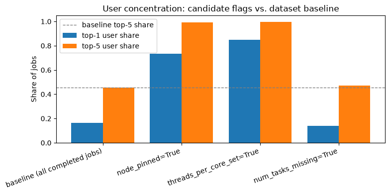

```python
fig, ax = plt.subplots(figsize=(8, 4))
x = np.arange(len(concentration_df))
ax.bar(x - 0.2, concentration_df["top1_share"], width=0.4, label="top-1 user share")
ax.bar(x + 0.2, concentration_df["top5_share"], width=0.4, label="top-5 user share")
ax.set_xticks(x)
ax.set_xticklabels(concentration_df["group"], rotation=20, ha="right")
ax.set_ylabel("Share of jobs")
ax.axhline(concentration_df.loc[0, "top5_share"], color="gray", linestyle="--", linewidth=1, label="baseline top-5 share")
ax.set_title("User concentration: candidate flags vs. dataset baseline")
ax.legend()
fig.tight_layout()
plt.show()
```

**Decision:**

| Flag | Effect size | Redundant? | User concentration | Verdict |
| --- | --- | --- | --- | --- |
| `node_pinned` | Real (power ~35% lower when pinned) | No | **99.3% in top-5 users** (73.5% in one) | Reserved, not active |
| `threads_per_core_set` | Largest (run_time ~4x, memory ~4x) | No (checked against partition/qos/GPU) | **85% in one user**, only 6 users ever | Reserved, not active |
| `num_tasks_missing` | Real (run_time ~2x higher when missing) | N/A (not an optional flag) | Top-5 = 47.1% of 101 users — close to dataset baseline | **Promoted to active Tier A** |

Both `node_pinned` and `threads_per_core_set` are computed and preserved (`src/features.py`'s `PM100_RESERVED_COLUMNS`) for a future dedicated, clearly-scoped analysis (e.g., a power-specific submodel) where the single-user-concentration caveat can be addressed directly — but neither enters the general Tier A feature set, despite `threads_per_core_set` having the largest raw effect size of the three. Effect size alone was not sufficient evidence; user concentration was the deciding factor. `num_tasks_missing` passes all three checks and is promoted.

### Check 4: Retroactive audit of already-active Tier A columns

Everything above vetted three *candidate* features before letting them in. It says nothing about columns that were already sitting in `PM100_TIER_A_COLUMNS` before this vetting process existed. Checking those too, rather than assuming the ones that arrived first are automatically fine.

```python
print("=== req_switch: value counts (full dataset) ===")
print(pm100_full_completed["req_switch"].value_counts(dropna=False) if "req_switch" in pm100_full_completed.columns else pm100_full["req_switch"].value_counts(dropna=False))

rare = pm100_full_completed[pm100_full_completed["req_switch"] != 0]
print(f"\nreq_switch != 0: n={len(rare)}, distinct users={rare['user_id'].nunique()}")
print(rare["user_id"].value_counts())
```

```
=== req_switch: value counts (full dataset) ===
req_switch
0    180297
1        13
Name: count, dtype: int64

req_switch != 0: n=13, distinct users=1
user_id
1650    13
Name: count, dtype: int64
```

**req_switch fails the same check just as badly as the excluded candidates** — only 13 non-zero rows across 180,310 completed jobs, and all 13 from a single user. This had been sitting in the active Tier A set since before this vetting process existed. Moved to `PM100_RESERVED_COLUMNS` alongside `req_nodes` and `threads_per_core`, with the same `req_switch_set` derived-flag treatment.

```python
print("=== shared: value counts (full dataset) ===")
print(pm100_full_completed["shared"].value_counts(dropna=False))
print("No comparable rare-value problem — both populated categories have tens of thousands of jobs, nowhere near single-user territory.")

print("\n=== qos / partition smallest categories ===")
for col in ["qos", "partition"]:
    vc = pm100_full_completed[col].value_counts()
    minority_val = vc.index[-1]
    sub = pm100_full_completed.loc[pm100_full_completed[col] == minority_val, "user_id"]
    share = sub.value_counts().iloc[0] / len(sub) if len(sub) else float("nan")
    print(f"{col} smallest category ({minority_val!r}): n={len(sub)}, distinct users={sub.nunique()}, top-1 user share={share:.1%}")
print("Both are legitimate multi-valued scheduling categoricals, not purpose-built rare binary flags — ordinary small-category variation here isn't the same red flag as a derived indicator with a single dominant user.")
```

```
=== shared: value counts (full dataset) ===
shared
OK    149226
0      31084
Name: count, dtype: int64
No comparable rare-value problem — both populated categories have tens of thousands of jobs, nowhere near single-user territory.

=== qos / partition smallest categories ===
```

```
qos smallest category ('7'): n=2, distinct users=1, top-1 user share=100.0%
partition smallest category ('2'): n=111, distinct users=8, top-1 user share=55.0%
Both are legitimate multi-valued scheduling categoricals, not purpose-built rare binary flags — ordinary small-category variation here isn't the same red flag as a derived indicator with a single dominant user.
```

### Split-strategy check: are heavy users spread across the full time span?

A separate concern from feature-level concentration: if a handful of users account for close to half of all jobs, does a **chronological** train/test split — training on earlier time, testing on later, the standard choice for HPC workload prediction since it avoids leaking future information into training — risk stranding a heavy user's jobs almost entirely on one side of the split? Checking whether PM100's heaviest users are active throughout the dataset's span, or clustered in a narrower window.

```python
full_start, full_end = pm100_full_completed["submit_time"].min(), pm100_full_completed["submit_time"].max()
full_span_days = (full_end - full_start).days
print(f"Full dataset span: {full_start.date()} to {full_end.date()} ({full_span_days} days)")

top5_users = pm100_full_completed["user_id"].value_counts().head(5).index
for uid in top5_users:
    sub = pm100_full_completed.loc[pm100_full_completed["user_id"] == uid, "submit_time"]
    span_days = (sub.max() - sub.min()).days
    coverage = span_days / full_span_days if full_span_days else float("nan")
    print(f"user {uid}: n={len(sub)}, active {sub.min().date()} to {sub.max().date()} ({span_days} days, {coverage:.0%} of full span)")
```

```
Full dataset span: 2020-05-06 to 2020-10-13 (159 days)
user 8: n=29690, active 2020-05-06 to 2020-10-13 (159 days, 100% of full span)
user 182: n=18207, active 2020-05-06 to 2020-10-08 (154 days, 97% of full span)
user 1711: n=14605, active 2020-05-11 to 2020-10-12 (154 days, 97% of full span)
user 1240: n=10942, active 2020-05-08 to 2020-10-12 (156 days, 98% of full span)
user 68: n=8410, active 2020-06-12 to 2020-10-11 (121 days, 76% of full span)
```

**Reassuring, but not the full picture.** PM100's top-5 heaviest users are each active across 97-100% of the dataset's full span (one exception at 76%, starting a month late but continuing to the end) — a chronological split would not strand any of them entirely in train or entirely in test. This check has only been run for PM100. F-DATA spans 38 months rather than 6, which is a much longer window for a heavy user's activity to plausibly taper off or shift before the dataset ends — that check still needs to be run there before the same reassurance can be extended to F-DATA's chronological split.

## Step 1c: F-DATA `avgpcon` units verification

`avgpcon`/`minpcon`/`maxpcon` are named like per-node power fields, but carry the same "job-total, not per-node" naming risk already found for PM100's `node_power_consumption` (see `src/features.py`'s module-level comment). Verifying directly here, the same way, rather than trusting the field name — two independent checks: correlation with node count, and a units cross-check against `econ`.

```python
# Check 1: correlation with node count (nnuma) -- if avgpcon were a genuine
# per-node reading, it should NOT scale up with more nodes. If it's a
# job-wide total, it should correlate strongly with nnuma.
avgpcon_nnuma_corr = fdata["avgpcon"].corr(fdata["nnuma"])
print(f"avgpcon vs nnuma correlation: {avgpcon_nnuma_corr:.4f}")

single_node = fdata.loc[fdata["nnuma"] == 1, "avgpcon"]
print(f"avgpcon for single-node jobs (nnuma==1): "
      f"min={single_node.min():.1f} W, max={single_node.max():.1f} W, n={len(single_node)}")
print("Compare against published A64FX per-node power figures as a plausibility check.")

features.assert_avgpcon_is_job_total(fdata)
print("avgpcon job-total assumption: OK")

# Check 2: units cross-check against econ (energy consumption). If avgpcon
# is genuinely in Watts, duration in seconds, and econ in Watt-hours, then
# econ / (avgpcon * duration) should be a near-constant ~1/3600 (the
# seconds-to-hours conversion), regardless of job size.
valid = (fdata["avgpcon"] > 0) & (fdata["duration"] > 0)
ratio = fdata.loc[valid, "econ"] / (fdata.loc[valid, "avgpcon"] * fdata.loc[valid, "duration"])
print(f"\necon / (avgpcon * duration): mean={ratio.mean():.6f}, "
      f"std={ratio.std():.6f}  (expected ~{1/3600:.6f})")
```

```
avgpcon vs nnuma correlation: 0.9727
avgpcon for single-node jobs (nnuma==1): min=39.5 W, max=164.1 W, n=2771
Compare against published A64FX per-node power figures as a plausibility check.
avgpcon job-total assumption: OK

econ / (avgpcon * duration): mean=0.000281, std=0.000033  (expected ~0.000278)
```

## Step 2: Tier A/B feature matrices

Re-running the leakage sanity check from notebook 01 on the post-exclusion data — this should still pass, but re-verifying after every transformation step matters because a silent bug in this custom pipeline code would invalidate results without anyone noticing otherwise.

```python
# Apply the Feature Vetting decision from Step 1b: derive the three
# indicators, then confirm the reserved ones are preserved but not
# leaked into the active Tier A set before building feature matrices.
fdata = features.handle_mszl_sentinel(fdata)
pm100 = features.add_pm100_derived_indicators(pm100)
features.assert_reserved_columns_preserved(pm100)

fdata_tier_a = features.build_tier_a_features(fdata, "fdata")
fdata_tier_b = features.build_tier_b_features(fdata, "fdata")
pm100_tier_a = features.build_tier_a_features(pm100, "pm100")
pm100_tier_b = features.build_tier_b_features(pm100, "pm100")

for name, cols, tier, dataset in [
    ("F-DATA Tier A", fdata_tier_a.columns, "A", "fdata"),
    ("F-DATA Tier B", fdata_tier_b.columns, "B", "fdata"),
    ("PM100 Tier A", pm100_tier_a.columns, "A", "pm100"),
    ("PM100 Tier B", pm100_tier_b.columns, "B", "pm100"),
]:
    features.assert_no_tier_leakage(list(cols), tier, dataset)
    print(f"{name}: {len(cols)} columns, OK")

print("\nreserved columns preserved:", [c for c in features.PM100_RESERVED_COLUMNS if c in pm100.columns])
print("num_tasks_missing in active Tier A:", "num_tasks_missing" in pm100_tier_a.columns)
```

```
F-DATA Tier A: 14 columns, OK
F-DATA Tier B: 30 columns, OK
PM100 Tier A: 16 columns, OK
PM100 Tier B: 15 columns, OK

reserved columns preserved: ['req_nodes', 'threads_per_core', 'req_switch', 'node_pinned', 'threads_per_core_set', 'req_switch_set']
num_tasks_missing in active Tier A: True
```

## Step 3: Embedding dimensionality reduction (Option C)

F-DATA only — PM100 has no job-name embedding field. Rather than picking an arbitrary component count, first check cumulative explained variance and pick the smallest number reaching 90% — then use that same PCA-reduced representation everywhere (tree models and DL alike, per Option C — the plan's original allowance for DL to use the full raw embedding is intentionally not exercised, to keep the memory profile safe unconditionally).

```
80% variance -> 32 components
90% variance -> 59 components
95% variance -> 91 components
99% variance -> 101 components
```

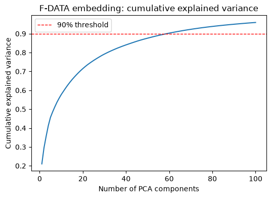

```
Using N_EMBEDDING_COMPONENTS=59 (90% explained variance) going forward
```

```python
pca_variance_check = features.compute_embedding_explained_variance(fdata, max_components=100)

import numpy as np
cumulative = np.cumsum(pca_variance_check.explained_variance_ratio_)
for threshold in [0.80, 0.90, 0.95, 0.99]:
    n = features.n_components_for_variance(pca_variance_check, threshold)
    print(f"{threshold:.0%} variance -> {n} components")

plt.figure(figsize=(6, 4))
plt.plot(range(1, len(cumulative) + 1), cumulative)
plt.axhline(0.90, color="r", linestyle="--", linewidth=1, label="90% threshold")
plt.xlabel("Number of PCA components")
plt.ylabel("Cumulative explained variance")
plt.title("F-DATA embedding: cumulative explained variance")
plt.legend()
plt.show()

N_EMBEDDING_COMPONENTS = features.n_components_for_variance(pca_variance_check, threshold=0.90)
print(f"\nUsing N_EMBEDDING_COMPONENTS={N_EMBEDDING_COMPONENTS} (90% explained variance) going forward")
```

```python
fdata_emb_pca = features.reduce_fdata_embedding(fdata, n_components=N_EMBEDDING_COMPONENTS)
print(fdata_emb_pca.shape)
fdata_emb_pca.describe().T
```

```
(4721, 59)
```

|  | count | mean | std | min | 25% | 50% | 75% | max |
| --- | --- | --- | --- | --- | --- | --- | --- | --- |
| emb_pc_0 | 4721.0 | 2.506400e-07 | 0.306849 | -0.594327 | -0.105534 | 0.051105 | 0.223923 | 0.404360 |
| emb_pc_1 | 4721.0 | 3.752277e-07 | 0.195714 | -0.248134 | -0.205161 | -0.040867 | 0.153298 | 0.489009 |
| emb_pc_2 | 4721.0 | 9.898335e-09 | 0.165471 | -0.498391 | -0.040616 | 0.034712 | 0.079842 | 0.229934 |
| emb_pc_3 | 4721.0 | -3.823990e-07 | 0.158814 | -0.332501 | -0.116131 | -0.020610 | 0.112668 | 0.464881 |
| emb_pc_4 | 4721.0 | 4.011856e-07 | 0.139996 | -0.594866 | -0.042149 | 0.032095 | 0.064365 | 0.240158 |
| emb_pc_5 | 4721.0 | -2.013503e-07 | 0.113794 | -0.397146 | -0.031860 | -0.014403 | 0.049610 | 0.379020 |
| emb_pc_6 | 4721.0 | 3.721724e-07 | 0.108630 | -0.322839 | -0.044961 | -0.005279 | 0.025102 | 0.505336 |
| emb_pc_7 | 4721.0 | -3.191708e-08 | 0.105003 | -0.389954 | -0.058060 | 0.004499 | 0.049769 | 0.406550 |
| emb_pc_8 | 4721.0 | -3.473508e-07 | 0.097789 | -0.341294 | -0.021576 | -0.003640 | 0.038492 | 0.343383 |
| emb_pc_9 | 4721.0 | 1.010034e-09 | 0.093798 | -0.415867 | -0.026465 | -0.004639 | 0.044460 | 0.331885 |
| emb_pc_10 | 4721.0 | 1.380717e-07 | 0.087412 | -0.260528 | -0.037948 | 0.000553 | 0.033088 | 0.239011 |
| emb_pc_11 | 4721.0 | -2.803855e-07 | 0.087065 | -0.332632 | -0.038223 | 0.004872 | 0.044926 | 0.254335 |
| emb_pc_12 | 4721.0 | 1.689787e-07 | 0.084894 | -0.327359 | -0.013979 | -0.004698 | 0.036709 | 0.278951 |
| emb_pc_13 | 4721.0 | 2.090771e-07 | 0.081442 | -0.284135 | -0.034780 | -0.000084 | 0.024889 | 0.317491 |
| emb_pc_14 | 4721.0 | 6.170804e-07 | 0.079752 | -0.291353 | -0.029548 | -0.010321 | 0.025222 | 0.346898 |
| emb_pc_15 | 4721.0 | 2.425345e-07 | 0.076022 | -0.207589 | -0.028711 | -0.003769 | 0.023857 | 0.342949 |
| emb_pc_16 | 4721.0 | 1.949366e-08 | 0.074190 | -0.236207 | -0.022662 | -0.000172 | 0.032325 | 0.243449 |
| emb_pc_17 | 4721.0 | 2.177129e-07 | 0.072809 | -0.269477 | -0.023943 | -0.001140 | 0.027358 | 0.204139 |
| emb_pc_18 | 4721.0 | 1.310519e-07 | 0.070370 | -0.317833 | -0.025705 | 0.000281 | 0.028230 | 0.239063 |
| emb_pc_19 | 4721.0 | -1.548382e-07 | 0.068178 | -0.303931 | -0.030700 | -0.001637 | 0.023944 | 0.258623 |
| emb_pc_20 | 4721.0 | -2.033199e-07 | 0.066148 | -0.244875 | -0.017993 | -0.001573 | 0.030340 | 0.248953 |
| emb_pc_21 | 4721.0 | 5.004719e-08 | 0.064156 | -0.191687 | -0.023747 | -0.003660 | 0.020825 | 0.322838 |
| emb_pc_22 | 4721.0 | 7.149779e-08 | 0.061455 | -0.251939 | -0.026079 | -0.000210 | 0.018294 | 0.308771 |
| emb_pc_23 | 4721.0 | 9.918536e-08 | 0.059866 | -0.233024 | -0.027785 | -0.000878 | 0.014719 | 0.275690 |
| emb_pc_24 | 4721.0 | -3.029598e-07 | 0.058710 | -0.229239 | -0.018508 | -0.005537 | 0.027137 | 0.200767 |
| emb_pc_25 | 4721.0 | 7.740650e-08 | 0.057092 | -0.208600 | -0.012110 | 0.000648 | 0.021041 | 0.217311 |
| emb_pc_26 | 4721.0 | -1.082252e-07 | 0.056239 | -0.238611 | -0.020059 | -0.001234 | 0.010477 | 0.287081 |
| emb_pc_27 | 4721.0 | 2.105416e-07 | 0.055281 | -0.210507 | -0.018454 | -0.001583 | 0.014066 | 0.313625 |
| emb_pc_28 | 4721.0 | -2.382418e-07 | 0.054343 | -0.225293 | -0.017045 | -0.003404 | 0.019475 | 0.258654 |
| emb_pc_29 | 4721.0 | -1.040335e-08 | 0.052038 | -0.209601 | -0.020849 | -0.002117 | 0.019841 | 0.214605 |
| emb_pc_30 | 4721.0 | 4.648051e-08 | 0.050613 | -0.237378 | -0.016036 | -0.002417 | 0.017363 | 0.218861 |
| emb_pc_31 | 4721.0 | -1.903915e-08 | 0.049874 | -0.243457 | -0.018956 | 0.000882 | 0.021047 | 0.240386 |
| emb_pc_32 | 4721.0 | 3.993675e-07 | 0.048694 | -0.235002 | -0.005353 | 0.000625 | 0.018976 | 0.212554 |
| emb_pc_33 | 4721.0 | -9.062532e-08 | 0.047650 | -0.221611 | -0.012623 | 0.001575 | 0.017035 | 0.208343 |
| emb_pc_34 | 4721.0 | 1.386651e-07 | 0.047193 | -0.253072 | -0.012399 | 0.000702 | 0.015723 | 0.186659 |
| emb_pc_35 | 4721.0 | -3.643698e-07 | 0.046085 | -0.180084 | -0.011609 | 0.002734 | 0.017663 | 0.167550 |
| emb_pc_36 | 4721.0 | 4.037612e-07 | 0.044879 | -0.221398 | -0.015398 | 0.002069 | 0.013882 | 0.226455 |
| emb_pc_37 | 4721.0 | -8.118655e-07 | 0.044428 | -0.217973 | -0.014248 | -0.001158 | 0.014266 | 0.218134 |
| emb_pc_38 | 4721.0 | -4.903716e-08 | 0.043664 | -0.298128 | -0.014922 | 0.005058 | 0.016478 | 0.191222 |
| emb_pc_39 | 4721.0 | -7.060139e-08 | 0.042986 | -0.205664 | -0.019057 | -0.001281 | 0.009161 | 0.210092 |
| emb_pc_40 | 4721.0 | -1.358244e-07 | 0.042015 | -0.205272 | -0.010150 | -0.000512 | 0.015696 | 0.166692 |
| emb_pc_41 | 4721.0 | -2.443147e-07 | 0.041918 | -0.183938 | -0.014774 | 0.004309 | 0.011014 | 0.193812 |
| emb_pc_42 | 4721.0 | -1.239312e-07 | 0.041390 | -0.217096 | -0.009170 | 0.001495 | 0.011575 | 0.245962 |
| emb_pc_43 | 4721.0 | 1.729305e-07 | 0.041280 | -0.156341 | -0.012910 | -0.001293 | 0.011042 | 0.213369 |
| emb_pc_44 | 4721.0 | 3.287661e-08 | 0.041149 | -0.202124 | -0.014140 | 0.000823 | 0.010731 | 0.168211 |
| emb_pc_45 | 4721.0 | -3.964384e-08 | 0.040047 | -0.293377 | -0.012040 | 0.000374 | 0.012411 | 0.243157 |
| emb_pc_46 | 4721.0 | -8.863050e-08 | 0.038925 | -0.161681 | -0.011143 | 0.000956 | 0.012002 | 0.186708 |
| emb_pc_47 | 4721.0 | -3.122079e-07 | 0.037669 | -0.153908 | -0.014718 | -0.001689 | 0.012030 | 0.216579 |
| emb_pc_48 | 4721.0 | -1.154153e-07 | 0.037613 | -0.177752 | -0.014301 | 0.000455 | 0.012401 | 0.169488 |
| emb_pc_49 | 4721.0 | -2.592758e-07 | 0.036988 | -0.160151 | -0.012630 | 0.000702 | 0.007844 | 0.209737 |
| emb_pc_50 | 4721.0 | -9.275902e-08 | 0.036507 | -0.149740 | -0.015495 | -0.000900 | 0.011279 | 0.183250 |
| emb_pc_51 | 4721.0 | -5.504687e-07 | 0.036015 | -0.205141 | -0.009381 | 0.001507 | 0.011675 | 0.227486 |
| emb_pc_52 | 4721.0 | -6.570273e-08 | 0.035903 | -0.151451 | -0.013763 | 0.000251 | 0.010174 | 0.213515 |
| emb_pc_53 | 4721.0 | -2.079408e-07 | 0.035583 | -0.184694 | -0.010773 | -0.000038 | 0.015464 | 0.138531 |
| emb_pc_54 | 4721.0 | -1.113184e-07 | 0.034870 | -0.205111 | -0.008231 | 0.000073 | 0.010596 | 0.169056 |
| emb_pc_55 | 4721.0 | 2.391761e-07 | 0.033844 | -0.198220 | -0.009303 | -0.002265 | 0.009019 | 0.179480 |
| emb_pc_56 | 4721.0 | -5.681443e-08 | 0.033649 | -0.229652 | -0.010114 | -0.000063 | 0.010088 | 0.142026 |
| emb_pc_57 | 4721.0 | 3.674631e-07 | 0.033329 | -0.173373 | -0.009522 | 0.000366 | 0.012890 | 0.146884 |
| emb_pc_58 | 4721.0 | -4.005101e-07 | 0.032840 | -0.227886 | -0.010380 | -0.000107 | 0.007989 | 0.165614 |

## Step 4: Historical rolling-stat features (Tier A)

```python
fdata_with_rolling = features.add_user_rolling_stat(fdata, "fdata", "duration", window=5)
pm100_with_rolling = features.add_user_rolling_stat(pm100, "pm100", "run_time", window=5)

n_fdata_available = fdata_with_rolling["duration_user_rolling_mean"].notna().sum()
n_pm100_available = pm100_with_rolling["run_time_user_rolling_mean"].notna().sum()
print(f"F-DATA: rolling stat available for {n_fdata_available}/{len(fdata_with_rolling)} jobs")
print(f"PM100: rolling stat available for {n_pm100_available}/{len(pm100_with_rolling)} jobs")

fdata_with_rolling[["usr", "adt", "duration", "duration_user_rolling_mean"]].head(10)
```

```
F-DATA: rolling stat available for 4426/4721 jobs
PM100: rolling stat available for 3717/3952 jobs
```

|  | usr | adt | duration | duration_user_rolling_mean |
| --- | --- | --- | --- | --- |
| 0 | usr_1365 | 2022-02-01 00:12:11+09:00 | 51.0 | 44.2 |
| 1 | usr_2448 | 2023-08-18 08:29:49+09:00 | 470.0 | 23.2 |
| 3 | usr_341 | 2022-02-27 14:18:27+09:00 | 14.0 | 18.6 |
| 4 | usr_1365 | 2022-02-07 06:34:36+09:00 | 69.0 | 69.8 |
| 5 | usr_2111 | 2023-08-29 19:26:20+09:00 | 101.0 | 997.6 |
| 6 | usr_1365 | 2022-02-08 17:43:14+09:00 | 95.0 | 122.6 |
| 7 | usr_1365 | 2022-02-01 05:00:05+09:00 | 192.0 | 123.0 |
| 8 | usr_244 | 2023-08-08 10:29:41+09:00 | 4.0 | 2404.0 |
| 9 | usr_445 | 2022-02-02 11:45:17+09:00 | 541.0 | NaN |
| 10 | usr_1365 | 2022-02-08 00:39:16+09:00 | 156.0 | 148.6 |

## Step 5: Target transforms

log1p on all three targets per dataset (execution time, memory, power — all heavy-tailed, dominated by many short/small jobs and a handful of huge ones) — training happens in log-space, metrics get reported in both log-space and back-transformed real units. Sanity-checking the round-trip here rather than assuming it.

```python
for name, targets, df in [("F-DATA", features.FDATA_TARGETS, fdata), ("PM100", features.PM100_TARGETS, pm100)]:
    for target_name, col in targets.items():
        raw = df[col].dropna().to_numpy()
        if len(raw) and hasattr(raw[0], "__len__"):
            # PM100 power: array-valued, reduce to per-job mean first (see notebook 01)
            raw = np.array([np.mean(a) for a in raw])
        raw = raw[raw >= 0].astype(float)
        transformed = features.transform_target(raw)
        recovered = features.inverse_transform_target(transformed)
        metrics.expm1_round_trip_check(raw)
        print(f"{name} {target_name} ({col}): round-trip OK, n={len(raw)}, "
              f"raw range [{raw.min():.2f}, {raw.max():.2f}], "
              f"log1p range [{transformed.min():.2f}, {transformed.max():.2f}]")
```

```
F-DATA execution_time (duration): round-trip OK, n=4721, raw range [1.00, 255677.00], log1p range [0.69, 12.45]
F-DATA memory (mmszu): round-trip OK, n=4721, raw range [23789568.00, 29637017600.00], log1p range [16.98, 24.11]
F-DATA power (avgpcon): round-trip OK, n=4721, raw range [39.53, 784526.52], log1p range [3.70, 13.57]
PM100 execution_time (run_time): round-trip OK, n=3952, raw range [0.00, 86328.00], log1p range [0.00, 11.37]
PM100 memory (mem_alloc): round-trip OK, n=3952, raw range [1.00, 60800.00], log1p range [0.69, 11.02]
PM100 power (node_power_consumption): round-trip OK, n=3952, raw range [480.00, 173911.93], log1p range [6.18, 12.07]
```

## Summary

This notebook validates the feature-engineering pipeline end to end on the dev sample: exclusion, Tier A/B separation, embedding reduction, rolling-stat features, and target transforms all pass their sanity checks. Nothing here is yet the "final" feature matrix used for training — that assembly happens in notebooks 05-07, reusing these same `src/features.py` functions against the full dataset once available.